# InVivoStat Single Measure Parametric Analysis

## Response and covariate

The Resp7 response is currently being analysed by the Single Measures Parametric Analysis module, with Cov6 fitted as a covariate.

## Scatterplot of the observed data

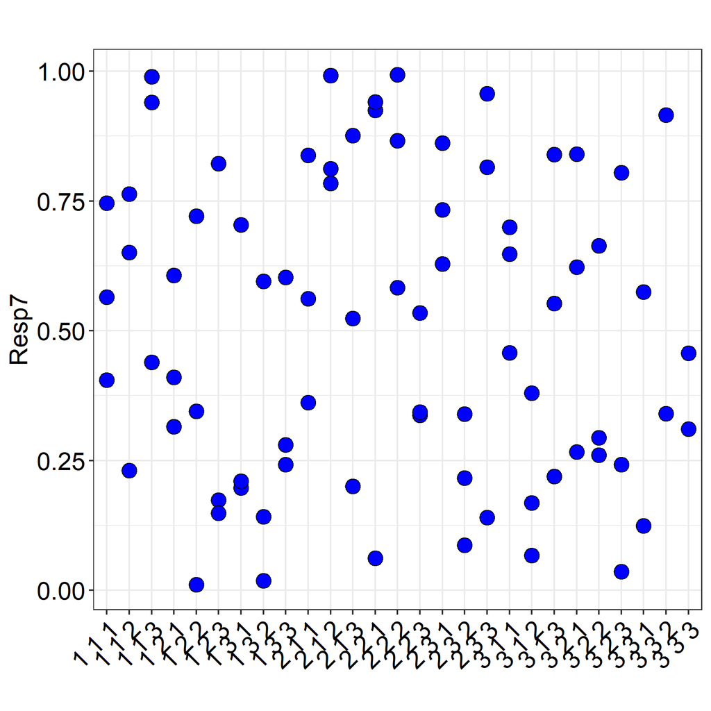

Tip: Use this plot to identify possible outliers.

## Plot of the response vs. the covariate, categorised by the primary factor

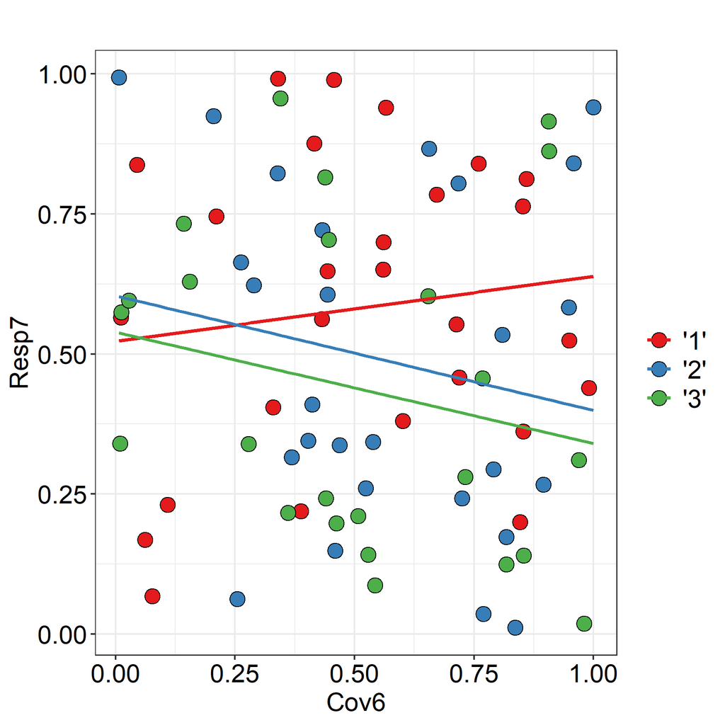

Tip: In order to decide whether it is helpful to fit the covariate, the following should be considered:

a) Is there a relationship between the response and the covariate? (N.B., It is only worth fitting the covariate if there is a strong positive (or negative) relationship between them: i.e., the lines on the plot should not be horizontal).

b) Is the relationship similar for all treatments? (The lines on the plot should be approximately parallel).

c) Is the covariate influenced by the treatment? (We assume the covariate is not influenced by the treatment and so there should be no separation of the treatment groups along the x-axis on the plot).

These issues are discussed in more detail in Morris (1999).

## Analysis of Covariance (ANCOVA) table for assessing covariate interactions

| Effect | Sums of squares | Degrees of freedom | Mean square | F-value | p-value |
| --- | --- | --- | --- | --- | --- |
| Cov6 | 0.133 | 1 | 0.133 | 1.65 | 0.2060 |
| Block3 | 0.120 | 2 | 0.060 | 0.75 | 0.4795 |
| Block4 | 0.036 | 1 | 0.036 | 0.44 | 0.5097 |
| Treat10 | 0.171 | 2 | 0.085 | 1.06 | 0.3551 |
| Treat9 | 0.019 | 2 | 0.010 | 0.12 | 0.8883 |
| Treat11 | 0.092 | 2 | 0.046 | 0.57 | 0.5699 |
| Treat10 * Treat9 | 0.227 | 4 | 0.057 | 0.70 | 0.5937 |
| Treat10 * Treat11 | 0.152 | 4 | 0.038 | 0.47 | 0.7552 |
| Treat9 * Treat11 | 0.206 | 4 | 0.051 | 0.64 | 0.6372 |
| Cov6 * Treat10 | 0.144 | 2 | 0.072 | 0.90 | 0.4160 |
| Cov6 * Treat9 | 0.024 | 2 | 0.012 | 0.15 | 0.8613 |
| Cov6 * Treat11 | 0.093 | 2 | 0.047 | 0.58 | 0.5650 |
| Treat10 * Treat9 * Treat11 | 0.812 | 8 | 0.102 | 1.26 | 0.2897 |
| Residual | 3.299 | 41 | 0.080 |  |  |

Note: This table should only be used to assess the covariate interactions. The statistical model used to generate all the remaining results in this output does not include the covariate interactions.

Comment: ANCOVA table calculated using a Type III model fit, see Armitage et al. (2001).

## Analysis of Covariance (ANCOVA) table

| Effect | Sums of squares | Degrees of freedom | Mean square | F-value | p-value |
| --- | --- | --- | --- | --- | --- |
| Cov6 | 0.066 | 1 | 0.066 | 0.86 | 0.3594 |
| Block3 | 0.155 | 2 | 0.078 | 1.01 | 0.3725 |
| Block4 | 0.044 | 1 | 0.044 | 0.57 | 0.4528 |
| Treat10 | 0.376 | 2 | 0.188 | 2.44 | 0.0978 |
| Treat9 | 0.257 | 2 | 0.129 | 1.67 | 0.1984 |
| Treat11 | 0.051 | 2 | 0.025 | 0.33 | 0.7212 |
| Treat10 * Treat9 | 0.273 | 4 | 0.068 | 0.89 | 0.4785 |
| Treat10 * Treat11 | 0.164 | 4 | 0.041 | 0.53 | 0.7122 |
| Treat9 * Treat11 | 0.221 | 4 | 0.055 | 0.72 | 0.5837 |
| Treat10 * Treat9 * Treat11 | 1.045 | 8 | 0.131 | 1.70 | 0.1235 |
| Residual | 3.613 | 47 | 0.077 |  |  |

Comment: ANCOVA table calculated using a Type III model fit, see Armitage et al. (2001).

Conclusion: At the 5% level, there are no statistically significant overall differences between the levels of any of the terms in the ANCOVA table.

Tip: While it is a good idea to consider the overall tests in the ANCOVA table, we should not rely on them when deciding whether or not to make pairwise comparisons.

## Model coefficients

|  | Estimate | Std. Error | t-value | p-value |
| --- | --- | --- | --- | --- |
| (Intercept) | 0.5535 | 0.0822 | 6.73 | < 0.0001 |
| Cov6 | -0.1230 | 0.1329 | -0.93 | 0.3594 |
| Block31 | -0.0655 | 0.0464 | -1.41 | 0.1644 |
| Block32 | 0.0366 | 0.0486 | 0.75 | 0.4548 |
| Block41 | 0.0334 | 0.0441 | 0.76 | 0.4528 |
| Treat101 | -0.0540 | 0.0445 | -1.21 | 0.2309 |
| Treat102 | 0.0973 | 0.0443 | 2.20 | 0.0330 |
| Treat91 | 0.0802 | 0.0451 | 1.78 | 0.0819 |
| Treat92 | -0.0220 | 0.0461 | -0.48 | 0.6353 |
| Treat111 | 0.0295 | 0.0459 | 0.64 | 0.5238 |
| Treat112 | -0.0331 | 0.0452 | -0.73 | 0.4680 |
| Treat101:Treat91 | 0.1016 | 0.0622 | 1.63 | 0.1088 |
| Treat102:Treat91 | -0.0071 | 0.0632 | -0.11 | 0.9108 |
| Treat101:Treat92 | -0.0322 | 0.0649 | -0.50 | 0.6219 |
| Treat102:Treat92 | 0.0250 | 0.0627 | 0.40 | 0.6917 |
| Treat101:Treat111 | -0.0418 | 0.0630 | -0.66 | 0.5101 |
| Treat102:Treat111 | 0.0126 | 0.0625 | 0.20 | 0.8413 |
| Treat101:Treat112 | -0.0340 | 0.0634 | -0.54 | 0.5946 |
| Treat102:Treat112 | 0.0578 | 0.0627 | 0.92 | 0.3609 |
| Treat91:Treat111 | -0.0383 | 0.0626 | -0.61 | 0.5440 |
| Treat92:Treat111 | 0.0333 | 0.0628 | 0.53 | 0.5987 |
| Treat91:Treat112 | -0.0165 | 0.0625 | -0.26 | 0.7924 |
| Treat92:Treat112 | 0.0683 | 0.0625 | 1.09 | 0.2801 |
| Treat101:Treat91:Treat111 | -0.0474 | 0.0887 | -0.53 | 0.5955 |
| Treat102:Treat91:Treat111 | -0.0972 | 0.0879 | -1.11 | 0.2741 |
| Treat101:Treat92:Treat111 | 0.0167 | 0.0878 | 0.19 | 0.8500 |
| Treat102:Treat92:Treat111 | -0.0603 | 0.0878 | -0.69 | 0.4953 |
| Treat101:Treat91:Treat112 | 0.0018 | 0.0878 | 0.02 | 0.9841 |
| Treat102:Treat91:Treat112 | 0.1963 | 0.0879 | 2.23 | 0.0303 |
| Treat101:Treat92:Treat112 | -0.0302 | 0.0878 | -0.34 | 0.7324 |
| Treat102:Treat92:Treat112 | 0.0999 | 0.0878 | 1.14 | 0.2609 |

## Covariate regression coefficient

| Covariate | Estimate | Std error | t-value | p-value |
| --- | --- | --- | --- | --- |
| Cov6 | -0.123 | 0.133 | -0.93 | 0.3594 |

## Diagnostic plots

### Residuals vs. predicted plot

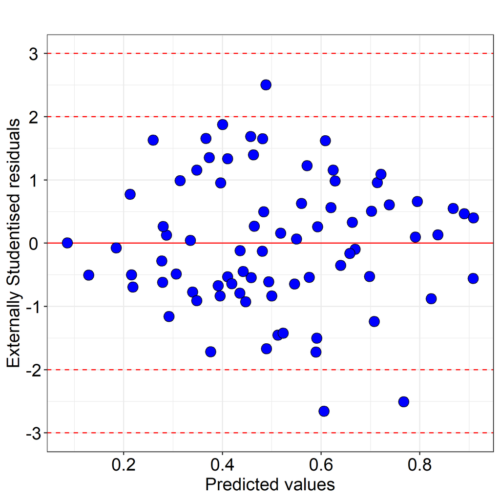

Tip: On this plot look to see if the spread of the points increases as the predicted values increase. If so the response may need transforming.

Tip: Any observation with a residual less than -3 or greater than 3 (SD) should be investigated as a possible outlier.

### Normal probability plot

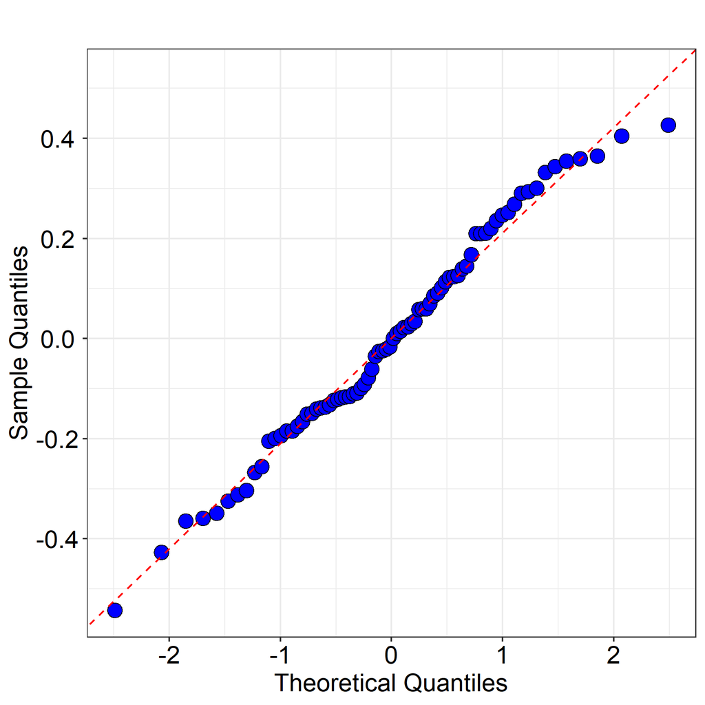

Tip: Check that the points lie along the dotted line. If not then the data may be non-normally distributed.

## Table of the least square (predicted) means with 95% confidence intervals

| Mean ID | Treat10 | Mean | Lower 95% CI | Upper 95% CI |
| --- | --- | --- | --- | --- |
| 1 | '1' | 0.434 | 0.318 | 0.550 |
| 2 | '2' | 0.585 | 0.467 | 0.704 |
| 3 | '3' | 0.445 | 0.319 | 0.571 |

## Plot of the least square (predicted) means with 95% confidence intervals

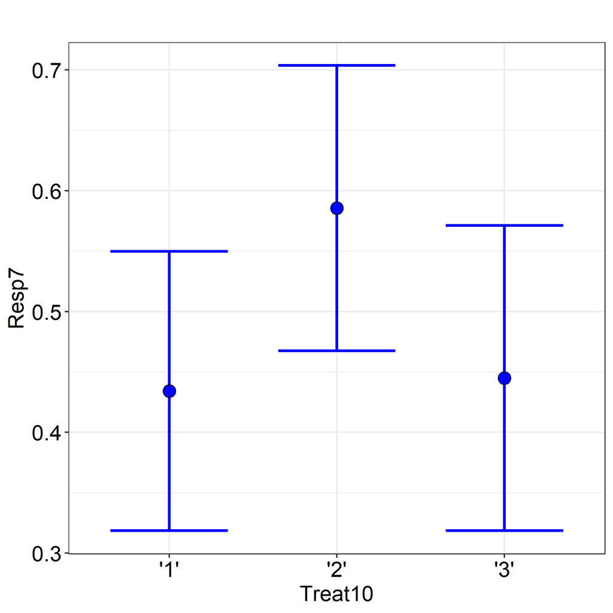

## All pairwise comparisons without adjustment for multiplicity (LSD test)

| Comparison | Difference | Lower 95% CI | Upper 95% CI | Std error | p-value |
| --- | --- | --- | --- | --- | --- |
| '1' - '2' | -0.151 | -0.304 | 0.001 | 0.076 | 0.0514 |
| '1' - '3' | -0.011 | -0.171 | 0.149 | 0.079 | 0.8924 |
| '2' - '3' | 0.141 | -0.019 | 0.300 | 0.079 | 0.0820 |

Conclusion: At the 5% level, there are no statistically significant pairwise comparisons.

Warning: It is not advisable to draw statistical inferences about a factor/interaction in the presence of a significant higher-order interaction involving that factor/interaction.

Warning: As these tests are not adjusted for multiplicity there is a risk of generating false positive results. Only use the pairwise tests you planned to make a-priori, these are the so called planned comparisons, see Snedecor and Cochran (1989).

## All to one comparisons without adjustment for multiplicity (LSD test)

| Comparison | Difference | Lower 95% CI | Upper 95% CI | Std error | p-value |
| --- | --- | --- | --- | --- | --- |
| '2' - '1' | 0.151 | -0.001 | 0.304 | 0.076 | 0.0514 |
| '3' - '1' | 0.011 | -0.149 | 0.171 | 0.079 | 0.8924 |

## Plot of the comparisons between the predicted means with 95% confidence intervals

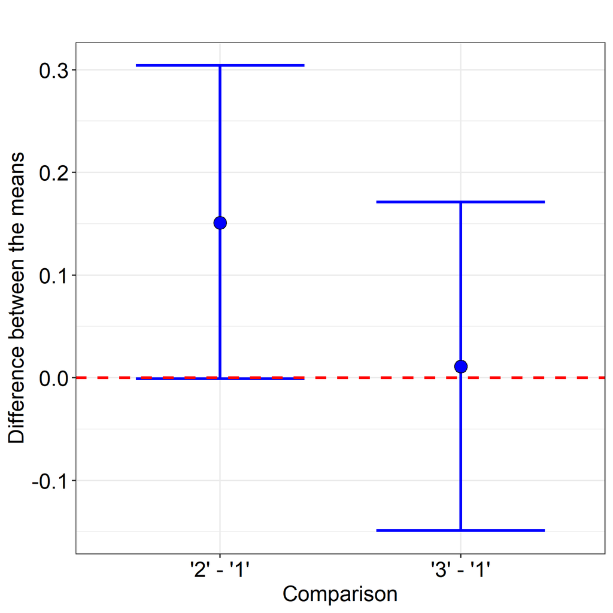

Conclusion: At the 5% level, there are no statistically significant pairwise comparisons.

Warning: It is not advisable to draw statistical inferences about a factor/interaction in the presence of a significant higher-order interaction involving that factor/interaction. In the above table certain higher order interactions are assumed to be not significant, see log for more details.

Warning: As these tests are not adjusted for multiplicity there is a risk of generating false positive results. Only use the pairwise tests you planned to make a-priori, these are the so called planned comparisons, see Snedecor and Cochran (1989).

## Analysis description

The data were analysed using a 3-way ANCOVA approach, with Treat10, Treat9 and Treat11 as the treatment factors, Block3 and Block4 as the blocking factors and Cov6 as the covariate.This was followed by Planned Comparisons of the predicted means to compare the levels of the Treat10 factor, Snedecor and Cochran (1989).

For more information on the theoretical approaches that are implemented within this module, see Bate and Clark (2014).

## References

When referring to InVivoStat, please cite 'InVivoStat, version 5.2.0'.

Bate, S.T. and Clark, R.A. (2014). The Design and Statistical Analysis of Animal Experiments. Cambridge University Press.

Armitage, P., Matthews, J.N.S. and Berry, G. (2001). Statistical Methods in Medical Research. 4th edition; John Wiley & Sons. New York.

Morris, T.R. (1999). Experimental Design and Analysis in Animal Sciences. CABI publishing. Wallingford, Oxon (UK).

Snedecor, G.W. and Cochran, W.G. (1989). Statistical Methods. 8th edition; Iowa State University Press, Iowa, USA.